# Big Data in Geographic Information Systems - Progetto d'esame

## David Govi - matricola 833653

Per questo progetto vengono presi in considerazione tre dataset.  
Il primo: Dati su osservazioni meteo prodotti da n stazioni metereologiche su territorio Norvegese.  
Il secondo: forecast meteo, un modello multilayer che descrive feature metereologiche in spazio e tempo.  
Il terzo: DEMs, ovvero Digital Elevation Model, contenenti dati sull'elevazione del suolo Norvegese.  
Lo scopo è quello di comparare dati osservazionali e forecast per valutare la qualità e l'accuratezza di quest'ultimi e successivamente associare l'errore osservato alle caratteristiche del terreno nei diversi punti dello spazio.

```python
from IPython.display import HTML

HTML('''<script>
code_show=true;
function code_toggle() {
 if (code_show){
 $('div.input').hide();
 } else {
 $('div.input').show();
 }
 code_show = !code_show
}
$( document ).ready(code_toggle);
</script>
<form action="javascript:code_toggle()"><input type="submit" value="Click here to toggle on/off the raw code."></form>''')
```

```python
import warnings
warnings.filterwarnings('ignore')
```

```python
import pickle
import requests
import pandas as pd
import random
from datetime import datetime
from netCDF4 import Dataset
import numpy as np
import os
import re
import time
from geopy import distance
from math import pi
from numpy import cos, sin
from scipy.spatial import cKDTree
import xarray as xr
import itertools
import sklearn.metrics as sm
import matplotlib.pyplot as plt
import multiprocessing as mp
import earthpy as et
import folium
from folium import plugins
from rasterio.warp import calculate_default_transform, reproject, Resampling
import rasterio as rio
from rasterio.plot import show
from sklearn import preprocessing
import xgboost as xgb
from sklearn.metrics import mean_squared_error
from sklearn.model_selection import train_test_split
import seaborn as sns
```

```python
class Kdtree_fast(object):
    def __init__(self, ncfile, latvarname, lonvarname):
        self.ncfile = ncfile
        self.latvar = self.ncfile.variables[latvarname]
        self.lonvar = self.ncfile.variables[lonvarname]
        # Read latitude and longitude from file into numpy arrays
        rad_factor = pi/180.0 # for trignometry, need angles in radians
        self.latvals = self.latvar[:] * rad_factor
        self.lonvals = self.lonvar[:] * rad_factor
        self.shape = self.latvals.shape
        clat,clon = cos(self.latvals),cos(self.lonvals)
        slat,slon = sin(self.latvals),sin(self.lonvals)
        clat_clon = clat*clon
        clat_slon = clat*slon
        triples = list(zip(np.ravel(clat*clon), np.ravel(clat*slon), np.ravel(slat)))
        self.kdt = cKDTree(triples)

    def query(self,lat0,lon0,k):
        rad_factor = pi/180.0
        lat0_rad = lat0 * rad_factor
        lon0_rad = lon0 * rad_factor
        clat0,clon0 = cos(lat0_rad),cos(lon0_rad)
        slat0,slon0 = sin(lat0_rad),sin(lon0_rad)
        dist_sq_min, minindex_1d = self.kdt.query([clat0*clon0,clat0*slon0,slat0],k=k)
        iy_min, ix_min = np.unravel_index(minindex_1d, self.shape)
        return iy_min,ix_min

ds = xr.open_dataset('/data/davidg/forecast/24h/January_18/meps_mbr0_pp_2_5km_20180123T00Z.nc')
ds.close()
ns = Kdtree_fast(ds,'latitude','longitude')
```

## Dataset 1 - Osservazioni

Per ottenere i dati osservazionali si deve inoltrare una query alle Frost API.  
source: https://frost.met.no/index.html  
La variabile metereologica su cui si sceglie di lavorare in questo caso è la temperatura dell'aria, essendo questa quella di più facile processamento e comprensione.  
La API restituisce informazioni sulla temperatura a risoluzione oraria, per un periodo di tempo che va dal 1 Gennaio 2018 al 1 Agosto 2018, per tutte le stazioni metereologiche che ne abbiano prodotte.

```python
client_id = '0c8bbb6c-7319-4468-8c63-cece03682584'
```

```python
#ESTRAGGO LA LISTA DELLE STAZIONI CHE RISPECCHIANO I PARAMETRI (INTERVALLO TEMPORALE, VARIABILE, RISOLUZIONE)
endpoint='https://frost.met.no/observations/availableTimeSeries/v0.jsonld'
parameters = {
    'referencetime':'2018-01-01/2018-08-01',
    'elements':'air_temperature',
    'timeresolutions':'PT1H',
    'levels':'2',
    'levelTypes':'height_above_ground'
}
r = requests.get(endpoint, parameters, auth=(client_id,''))
json = r.json()
```

```python
#ESTRAGGO GLI ID DI QUESTE STAZIONI
available_stations=[]
for i in range(0,len(json['data'])):
    if json['data'][i]['level']['value']==2:
        available_stations.append(json['data'][i]['sourceId'])
```

```python
stations=available_stations
#PULISCO LE STRINGHE CONTENENTI GLI ID PER ESSERE SICURO DI MATCHARE CORRETTAMENTE
for i in range(0,len(stations)):
    stations[i] = re.sub(r'\:0', '', stations[i])
    stations[i] = re.sub(r'\:1', '', stations[i])
    stations[i] = re.sub(r'\:2', '', stations[i])
```

```python
uni_stations=list(set(stations))
```

```python
#CHIEDO INFO SU TUTTE LE STAZIONI
endpoint = 'https://frost.met.no/sources/v0.jsonld'
parameters = {
}
r = requests.get(endpoint, parameters, auth=(client_id,''))
# Extract JSON data
json = r.json()
```

```python
#FACCIO UNA LISTA CON L'ID DI TUTTE LE STAZIONI
all_stations=[]
for i in range(0,len(json['data'])):
    all_stations.append(json['data'][i]['id'])
```

```python
#CONTROLLO L'INDICE CHE HANNO LE STAZIONI ESTRATTE ALL'INTERNO DELLA LISTA TOTALE
ind=[]
for i in uni_stations:
    if i in all_stations:
        ind.append(all_stations.index(i))
```

Tramite un breve preprocessing si riescono ad ottenere i dati relativi a tutte le stazioni che abbiano prodotto osservazioni realtive alla temperatura, per le date richieste.  
Per ogni stazione metereologica si hanno a disposizione le coordinate spaziali, il nome, e il codice identificativo.

```python
#ESTRAGGO LE INFORMAZIONI RILEVANTI PER LE STAZIONI
infos=[]
#for i in range(0,len(ind)):
for i in range(0,len(ind)):
    try:
        infos.append((json['data'][ind[i]]['name'],
                        json['data'][ind[i]]['geometry']['coordinates'],
                        json['data'][ind[i]]['id']))
    except KeyError:
        continue

from operator import itemgetter
infos=sorted(infos, key=itemgetter(0))
infos
```

```python
lats=np.arange(517390,738591,1)/10000
lons=np.arange(-143620,486741,1)/10000
```

```python
infos=[i for i in infos if (i[1][0] in lons) and (i[1][1] in lats)]
```

Si restringe leggermente il campo di ricerca, limitandosi alle stazioni metereologiche presenti all'interno dei boundaries per cui sono prodotti i forecast meteo.

```python
infos
```

```
[('ALTA LUFTHAVN', [23.3582, 69.9775], 'SN93140'),
 ('ALVDAL', [10.6268, 62.1093], 'SN8880'),
 ('ANDØYA', [16.1312, 69.3073], 'SN87110'),
 ('ANDØYA - TROLLTINDEN', [16.003, 69.2413], 'SN87120'),
 ('ARENDAL LUFTHAVN', [8.7028, 58.5158], 'SN36330'),
 ('ARNØYA - TROLLTINDEN', [20.431, 70.075], 'SN91729'),
 ('ASKER', [10.4358, 59.8558], 'SN19710'),
 ('ASKIM - KYKKELSRUD', [11.0962, 59.5873], 'SN3720'),
 ('ASKIM II', [11.166, 59.5872], 'SN3810'),
 ('AURSKOG II', [11.5801, 59.9119], 'SN2650'),
 ('AUSTEVOLL', [5.2038, 60.0167], 'SN50175'),
 ('BALESTRAND - BALE', [6.5285, 61.2028], 'SN55928'),
 ('BANAK', [24.99, 70.06], 'SN95350'),
 ('BARDUFOSS', [18.5437, 69.0577], 'SN89350'),
 ('BEITOSTØLEN II', [8.9228, 61.2508], 'SN23550'),
 ('BERGELIGREND', [9.058, 59.8861], 'SN30860'),
 ('BERGEN - FLORIDA', [5.3327, 60.383], 'SN50540'),
 ('BERGEN - FLORIDA UIB', [5.332, 60.3837], 'SN50539'),
 ('BERGEN - SANDSLI', [5.2776, 60.2913], 'SN50480'),
 ('BERLEVÅG LUFTHAVN', [29.0348, 70.8708], 'SN98090'),
 ('BIRTAVARRE - HOLMEN', [20.8693, 69.4802], 'SN91551'),
 ('BJORLI', [8.2, 62.2583], 'SN61630'),
 ('BJØRNFJELL', [18.0767, 68.4323], 'SN84900'),
 ('BJØRNHOLT', [10.6878, 60.0513], 'SN18500'),
 ('BLÅSJØ', [6.8817, 59.3335], 'SN40510'),
 ('BODØ - SKIVIKA', [14.4309, 67.3084], 'SN82310'),
 ('BODØ VI', [14.3637, 67.267], 'SN82290'),
 ('BRUSDALSVATN II', [6.4013, 62.4654], 'SN60890'),
 ('BRØNNØYSUND LUFTHAVN', [12.2182, 65.4567], 'SN76330'),
 ('BUHOLMRÅSA FYR', [10.455, 64.4013], 'SN71990'),
 ('BULKEN', [6.222, 60.6455], 'SN51470'),
 ('BUSNES', [8.9863, 59.8103], 'SN30875'),
 ('BYGLANDSFJORD - NESET', [7.803, 58.6863], 'SN39750'),
 ('BÅTSFJORD - STRAUMSNESAKSLA', [29.7, 70.6028], 'SN98360'),
 ('BØ', [9.0287, 59.4175], 'SN32240'),
 ('BØ I VESTERÅLEN III', [14.4333, 68.6067], 'SN86740'),
 ('DAGALI LUFTHAVN', [8.5263, 60.4188], 'SN29720'),
 ('DIVIDALEN II', [19.7017, 68.7817], 'SN89940'),
 ('DOVRE-LANNEM', [9.2143, 62.0172], 'SN16400'),
 ('DRAG - AJLUOKTA', [16.0838, 68.0472], 'SN83710'),
```

[output cut: 364 more lines]

```
 ('ÅNDALSNES - KAMSHAUGEN', [7.672, 62.5643], 'SN61340'),
 ('ÅNSTADBLÅHEIA', [15.3112, 68.7183], 'SN87000'),
 ('ÅRNES', [11.3933, 60.1268], 'SN4920'),
 ('ÅS', [10.7818, 59.6605], 'SN17850'),
 ('ÅS - RUSTADSKOGEN', [10.8107, 59.6703], 'SN17870'),
 ('ÅSANE', [5.3418, 60.4742], 'SN50810'),
 ('ÅSERAL', [7.4128, 58.6172], 'SN41480'),
 ('ØKSFJORD - DEALLJA', [22.3413, 70.1728], 'SN92860'),
 ('ØRLAND III', [9.6105, 63.7045], 'SN71550'),
 ('ØRSKOG', [6.8167, 62.4775], 'SN60800'),
 ('ØRSTA - EITREFJELL', [6.2877, 62.16], 'SN59695'),
 ('ØRSTA-VOLDA LUFTHAMN', [6.0807, 62.181], 'SN59680'),
 ('ØSAKER', [11.0422, 59.3193], 'SN3370'),
 ('ØSTRE TOTEN - APELSVOLL', [10.8695, 60.7002], 'SN11500'),
 ('ØVRE HEIMDALSVATN', [8.8945, 61.4183], 'SN13750')]
```

Si visualizzano su mappa tutte le stazioni a cui si è potuto attingere per recuperare dati sulla temperatura.

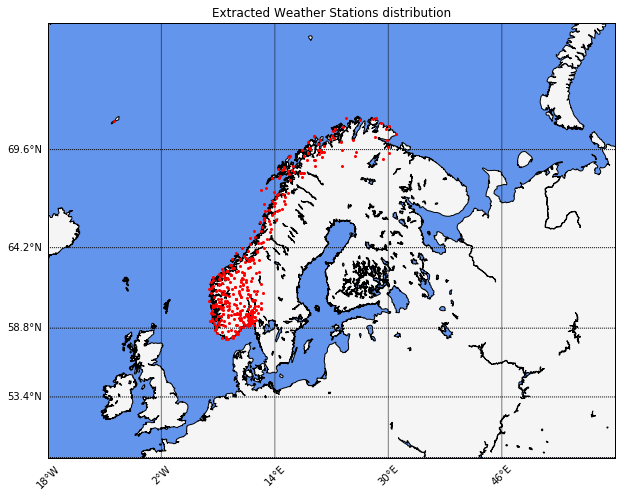

```python
#PLOTTO LA POSIZIONE DELLE 10 STAZIONI ESTRATTE
%matplotlib inline
from matplotlib import pyplot as plt
from mpl_toolkits.basemap import Basemap


lats, lons = [],[]
for i in range(0,len(infos)):
    try:
        lons.append(infos[i][1][0])
        lats.append(infos[i][1][1])
    except KeyError:
        continue


# How much to zoom from coordinates (in degrees)
zoom_scale = 0

# Setup the bounding box for the zoom and bounds of the map
bbox = [48.0,75.0,\
        -18.0,62.0]

plt.figure(figsize=(12,8))
# Define the projection, scale, the corners of the map, and the resolution.
m = Basemap(projection='merc',llcrnrlat=bbox[0],urcrnrlat=bbox[1],\
            llcrnrlon=bbox[2],urcrnrlon=bbox[3],lat_ts=10,resolution='i')

# Draw coastlines and fill continents and water with color
m.drawcoastlines()
m.fillcontinents(color='whitesmoke',lake_color='cornflowerblue')

# draw parallels, meridians, and color boundaries
m.drawparallels(np.arange(bbox[0],bbox[1],(bbox[1]-bbox[0])/5),labels=[1,0,0,0])
m.drawmeridians(np.arange(bbox[2],bbox[3],(bbox[3]-bbox[2])/5),labels=[0,0,0,1],rotation=45)
m.drawmapboundary(fill_color='cornflowerblue')

# build and plot coordinates onto map
x,y = m(lons,lats)
m.plot(x,y,'ro',markersize=2)
plt.title("Extracted Weather Stations distribution")
#plt.savefig('Weather_stations.png', format='png', dpi=500)
plt.show()
```

Si effettua finalmente la query per ogni stazione e si ottiene un dataframe conn tutte le osservazioni richieste.

```python
d = {'time': [], 'observed_air_temperature': [], 'weather_station': [], 'code': []}
obstot=pd.DataFrame(d)
empty=[]
partial=[]

for i in range(0,len(infos)):

    endpoint='https://frost.met.no/observations/v0.jsonld'
    parameters = {
        'sources':'{}'.format(infos[i][2]),
        'referencetime':'2018-01-01/2018-02-01',
        'elements':'air_temperature',
        'timeresolutions':'PT1H',
        'levels':'2'
    }
    r = requests.get(endpoint, parameters, auth=(client_id,''))
    # Extract JSON data
    json = r.json()

    # This will return a Dataframe with all of the observations in a table format
    try:
        data=json['data']
    except KeyError:
        empty.append(infos[i])
        continue
    obs = pd.DataFrame()
    for j in range(len(data)):
        row = pd.DataFrame(data[j]['observations'])
        row['referenceTime'] = data[j]['referenceTime']
        row['observed_air_temperature'] = data[j]['observations'][0]['value']
        obs = obs.append(row)
    obs = obs.reset_index()

    obs=obs.drop(columns=list(obs)[:-2])
    obs.columns=['time','observed_air_temperature']
    obs['weather_station']=infos[i][0]
    obs['code']=infos[i][2]
    if len(obs) == 744:
        obstot=pd.concat([obstot,obs])
    else:
        partial.append(infos[i])
```

```python
obstot.reset_index(inplace=True)
obstot.sort_values(by=['code','time'], inplace=True)
```

```python
obstot.head()
```

|  | index | time | observed_air_temperature | weather_station | code |
| --- | --- | --- | --- | --- | --- |
| 2976 | 0 | 2018-01-01T00:00:00.000Z | 4.0 | ARENDAL LUFTHAVN | SN36330 |
| 2977 | 1 | 2018-01-01T01:00:00.000Z | 3.8 | ARENDAL LUFTHAVN | SN36330 |
| 2978 | 2 | 2018-01-01T02:00:00.000Z | 3.7 | ARENDAL LUFTHAVN | SN36330 |
| 2979 | 3 | 2018-01-01T03:00:00.000Z | 3.8 | ARENDAL LUFTHAVN | SN36330 |
| 2980 | 4 | 2018-01-01T04:00:00.000Z | 3.8 | ARENDAL LUFTHAVN | SN36330 |

## Dataset 2 - Forecast

I forecast meteo sono prodotti dal Norwegian Metereological Institute.  
source: http://thredds.met.no/thredds/catalog/meps25epsarchive/catalog.html  
Con una risoluzione di 2.5km i forecast forniscono dati su tutte le feature meteologiche a cadenza oraria.

e.g.

```python
forecast_tipo = xr.open_dataset('/Users/davidgovi/Downloads/meps_mbr0_vc_2_5km_20180101T00Z.nc')
```

```python
forecast_tipo
```

```
<xarray.Dataset>
Dimensions:                          (height0: 1, height_above_msl: 1, hybrid: 65, nvcross: 651, time: 67, two: 2, x: 28313, y: 1)
Coordinates:
  * time                             (time) datetime64[ns] 2018-01-01 ... 2018-01-03T18:00:00
  * height_above_msl                 (height_above_msl) float32 0.0
  * height0                          (height0) float32 0.0
  * hybrid                           (hybrid) float64 0.009869 ... 0.9985
  * x                                (x) float64 0.0 1.0 ... 2.831e+04 2.831e+04
  * y                                (y) float64 0.0
    latitude                         (y, x) float32 58.416668 ... 60.629818
    longitude                        (y, x) float32 4.0 4.042932 ... 8.566335
Dimensions without coordinates: nvcross, two
Data variables:
    p0                               float64 1.013e+05
    ap                               (hybrid) float64 1e+03 3e+03 ... 0.0 0.0
    b                                (hybrid) float64 0.0 0.0 ... 0.9956 0.9985
    specific_humidity_ml             (time, hybrid, y, x) float64 ...
    atmosphere_cloud_ice_content_ml  (time, hybrid, y, x) float32 ...
    snowfall_amount_ml               (time, hybrid, y, x) float32 ...
    rainfall_amount_ml               (time, hybrid, y, x) float64 ...
    graupelfall_amount_ml            (time, hybrid, y, x) float64 ...
    turbulent_kinetic_energy_ml      (time, hybrid, y, x) float64 ...
    cloud_area_fraction_ml           (time, hybrid, y, x) float32 ...
    air_temperature_ml               (time, hybrid, y, x) float64 ...
    x_wind_ml                        (time, hybrid, y, x) float64 ...
    y_wind_ml                        (time, hybrid, y, x) float64 ...
    surface_air_pressure             (time, height0, y, x) float32 ...
    surface_geopotential             (time, height0, y, x) float32 ...
    upward_air_velocity_ml           (time, hybrid, y, x) float64 ...
    vcross_name                      (nvcross) |S80 b'(58N;4E)-(58N;14E)' ... b'AAL - \xc5L I HALLINGDAL'
    vcross_bnds                      (nvcross, two) int32 0 232 ... 28312 28312
Attributes:
    history:                    Mon Jan  1 02:15:00 2018: ncrcat -4 -A --chun...
    history_of_appended_files:  Mon Jan  1 02:15:00 2018: Appended file vc_00...
    NCO:                        "4.5.4"
    nco_openmp_thread_number:   1
```

Una volta scaricati tutti i forecast necessari, da ognuno di essi si fanno uno slicing sulla variabile *air_temperature_2m* e si costruisce un dataframe contenente, per le coordinate relative ad ogni stazione metereologica precedentemente indicata, le informazioni meteo forecasted per il range temporale preso in considerazione.

```python
directory = os.fsencode('/data/davidg/forecast/24h/January_18')
files=[] #lista dei file dei forecast presenti nella cartella
for file in os.listdir(directory):
    files.append(os.fsdecode(file))
files=sorted(files)
```

```python
def fs_kneighbours_interp(k):
    d = {'forecasted_air_temperature': [],'time':[], 'code':[]}
    forecast = pd.DataFrame(data=d)
    for i in files:
        fs = xr.open_dataset('/data/davidg/forecast/24h/January_18/{}'.format(i))
        temperature=fs['air_temperature_2m']
        t=fs['time'][:24]
        lat_array = fs['latitude']
        lon_array = fs['longitude']
        fs.close()
        for j in infos:
            indexes = ns.query(j[1][1],j[1][0],k)
            neighbours=[([lon_array[w,z].values,lat_array[w,z].values]) for w,z in zip(indexes[0],indexes[1])]
            num=0
            den=0
            for q in range(len(neighbours)):
                geodist=distance.distance([neighbours[q][1],neighbours[q][0]],[j[1][1],j[1][0]]).m
                num=num+(temperature[:24,0,indexes[0][q],indexes[1][q]]/geodist)
                den=den+(1/geodist)
            idw=num/den
            n={'forecasted_air_temperature': np.array(idw.values-273.15),
               'time':t,
               'code':j[2]}
            df=pd.DataFrame(n)
            forecast=pd.concat([forecast, df])
    return forecast
```

I forecast hanno una risoluzione spaziale di 2.5km.  
Quello che si può fare come primo approccio è, dato un set di coordinate, prendere i valori dalla cella più vicina. Un metodo più accurato però può essere quello di eseguire un'interpolazione IDW (Inverse Distance Weighting).  
Per ogni set di coordinate quindi si individuano le 3 celle più vicine all'interno del modello, se ne estraggono i valori e si calcola la loro distanza geodetica dal punto di interesse.  
Da queste informazioni si ricava una stima da proporre come valore prodotto dal modello forecast per l'esatto punto richiesto.

```python
forecast=fs_kneighbours_interp(3)
```

Si fa un join tra i dataframe di osservazioni e forecast in modo da poter stimare, per ogni stazione, per ogni ora, l'accuratezza dei forecast stessi.

```python
airtemp = obstot.merge(forecast, on=['code', 'time'])

airtemp['observed_air_temperature']=airtemp['observed_air_temperature']+273.15
airtemp['forecasted_air_temperature']=airtemp['forecasted_air_temperature']+273.15
```

```python
airtemp=pd.read_csv('/Users/davidgovi/Desktop/sintef/full_3n_airtemp_obsvsfor_24hfs.csv', index_col=0)
```

```python
airtemp.head()
```

|  | level_0 | index_x | time | observed_air_temperature | weather_station | code | Unnamed: 0.1 | index_y | forecasted_air_temperature | error |
| --- | --- | --- | --- | --- | --- | --- | --- | --- | --- | --- |
| 0 | 1363584 | 0 | 2018-01-01 00:00:00 | 269.85 | SØLENDET | SN10800 | 7608 | 0 | 271.972937 | -2.122937 |
| 1 | 1363585 | 1 | 2018-01-01 01:00:00 | 267.35 | SØLENDET | SN10800 | 7609 | 1 | 272.661658 | -5.311658 |
| 2 | 1363586 | 2 | 2018-01-01 02:00:00 | 267.95 | SØLENDET | SN10800 | 7610 | 2 | 272.834418 | -4.884418 |
| 3 | 1363587 | 3 | 2018-01-01 03:00:00 | 268.05 | SØLENDET | SN10800 | 7611 | 3 | 273.239172 | -5.189172 |
| 4 | 1363588 | 4 | 2018-01-01 04:00:00 | 269.15 | SØLENDET | SN10800 | 7612 | 4 | 272.981329 | -3.831329 |

```python
airtemp.drop(['level_0','index_x','Unnamed: 0.1', 'index_y', 'error'], axis=1, inplace=True)
```

```python
airtemp['time'] = airtemp['time'].apply(lambda x: datetime.strptime(x, '%Y-%m-%d %H:%M:%S'))
```

```python
######raggruppare osservazionie  forecast sul giorno
```

Si aggregano sia forecast che osservazioni riducendo la risoluzione a giornaliera.

```python
airtemp['day']=airtemp['time'].apply(lambda x: x.day)
airtemp['week']=airtemp['time'].apply(lambda x: x.week)
airtemp['month']=airtemp['time'].apply(lambda x: x.month)
```

```python
airtemp=airtemp.groupby(['day','week','month','code','weather_station']).mean()
```

```python
airtemp.reset_index(inplace=True)
airtemp.sort_values(by=['weather_station','month','day'], inplace=True)
```

```python
y=airtemp['observed_air_temperature']
x=airtemp['forecasted_air_temperature']
airtemp['error']=x-y
```

```python
mae = sm.mean_absolute_error(x,y)
mdae = sm.median_absolute_error(x,y)
sde = np.std(airtemp['error'])
rmse = np.sqrt(sm.mean_squared_error(x, y))
cor = np.corrcoef(np.array(airtemp['observed_air_temperature']),np.array(airtemp['forecasted_air_temperature']))[1,0]
```

Si calcolano varie metriche d'errore per avere una stima della qualità dei forecast overall.

```python
print('Mean absolute error: ',mae,'\nMedian absolute error: ',mdae,'\nStandard deviation of error: ',sde,
     '\nRoot mean squared error: ',rmse,'\nCorrelation: ',cor,'\nMax error: ',max(airtemp['error'],key=abs),
     '\nMin error: ',min(airtemp['error'],key=abs))
```

```
Mean absolute error:  1.2011185840359226
Median absolute error:  0.8518008958333212
Standard deviation of error:  1.6701730469697347
Root mean squared error:  1.692729526762211
Correlation:  0.9852491512609692
Max error:  14.75949964583333
Min error:  9.929166651545529e-06
```

Può essere interessante considerare la distribuzione dell'errore giornaliero nelle varie stazioni. Dall'istogramma si può evincere come quando i forecast sottostimano il valore osservato si ottenga un errore leggermente più basso.

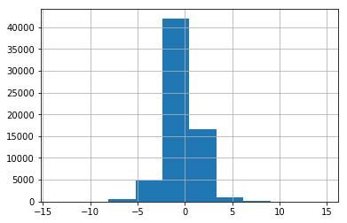

```python
airtemp['error'].hist()
```

Tramite alcuni hexagon plot si può tentare di capire meglio che cosa condizioni la qualità dei forecast.

```python
####plottare hexagon errore vs periodo dell'anno (giorno, settimana, mese)
```

Da un primo plot si nota come l'errore dei forecast aumenti di misura e di varibilità tanto più si stimano temperature inferiori ai 273.15 Kelvin.  
Si accettasse di considerare valori inferiori allo 0° Celsius come *eventi estremi*, si potrebbe affermare che l'affidabilità dei forecast diminuisce quanto più si tenta di predirre eventi estremi.

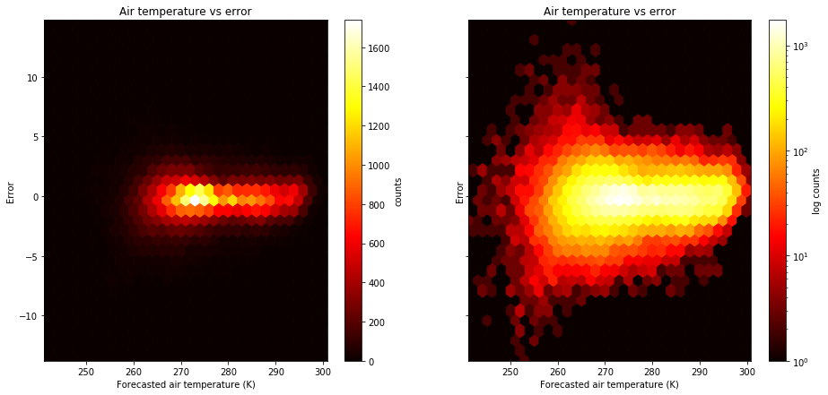

```python
x = airtemp['forecasted_air_temperature']
y = airtemp['error']
xmin = x.min()
xmax = x.max()
ymin = y.min()
ymax = y.max()

fig, axs = plt.subplots(ncols=2, sharey=True, figsize=(14, 7))
fig.subplots_adjust(hspace=0.5, left=0.07, right=0.93)

ax = axs[0]
hb = ax.hexbin(x, y, gridsize=30, cmap='hot')
ax.axis([xmin, xmax, ymin, ymax])
title = ax.set_title("Air temperature vs error")
ax.set_xlabel('Forecasted air temperature (K)')
ax.set_ylabel('Error')
cb = fig.colorbar(hb, ax=ax)
cb.set_label('counts')

ax = axs[1]
hb = ax.hexbin(x, y, gridsize=30, bins='log', cmap='hot')
ax.axis([xmin, xmax, ymin, ymax])
title="Air temperature vs error"
ax.set_title(title)
ax.set_xlabel('Forecasted air temperature (K)')
ax.set_ylabel('Error')
cb = fig.colorbar(hb, ax=ax)
cb.set_label('log counts')

plt.show()
```

Da un secondo hexagon plot si nota come la varianza dell'errore non sia la stessa durante i vari mesi dell'anno. Si nota come, a parziale conferma della conclusione tratta dal precedente plot, i mesi invernali, e quindi più rigidi, presentino una varianza dell'errore maggiore ai mesi successivi.

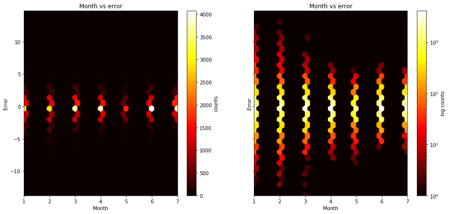

```python
x = airtemp['month']
y = airtemp['error']
xmin = x.min()
xmax = x.max()
ymin = y.min()
ymax = y.max()

fig, axs = plt.subplots(ncols=2, sharey=True, figsize=(14, 7))
fig.subplots_adjust(hspace=0.5, left=0.07, right=0.93)

ax = axs[0]
hb = ax.hexbin(x, y, gridsize=30, cmap='hot')
ax.axis([xmin, xmax, ymin, ymax])
title="Month vs error"
ax.set_title(title)
ax.set_xlabel('Month')
ax.set_ylabel('Error')
cb = fig.colorbar(hb, ax=ax)
cb.set_label('counts')

ax = axs[1]
hb = ax.hexbin(x, y, gridsize=30, bins='log', cmap='hot')
ax.axis([xmin, xmax, ymin, ymax])
ax.set_title("Month vs error")
ax.set_xlabel('Month')
ax.set_ylabel('Error')
cb = fig.colorbar(hb, ax=ax)
cb.set_label('log counts')

plt.show()
```

Più in dettaglio, al di là di evidenti missing values, si può notare lo stesso trend plottando per le settimane dell'anno.

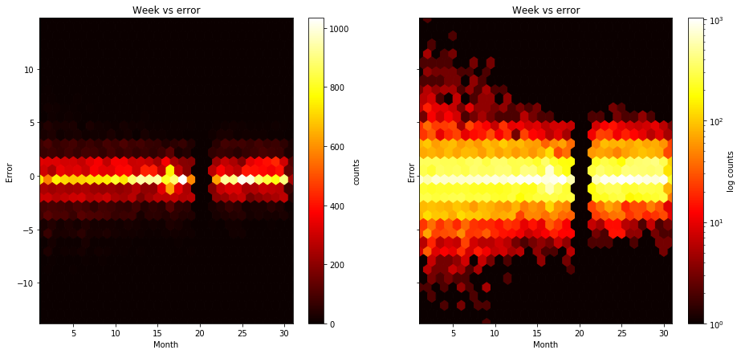

```python
x = airtemp['week']
y = airtemp['error']
xmin = x.min()
xmax = x.max()
ymin = y.min()
ymax = y.max()

fig, axs = plt.subplots(ncols=2, sharey=True, figsize=(14, 7))
fig.subplots_adjust(hspace=0.5, left=0.07, right=0.93)

ax = axs[0]
hb = ax.hexbin(x, y, gridsize=30, cmap='hot')
ax.axis([xmin, xmax, ymin, ymax])
title="Week vs error"
ax.set_title(title)
ax.set_xlabel('Month')
ax.set_ylabel('Error')
cb = fig.colorbar(hb, ax=ax)
cb.set_label('counts')

ax = axs[1]
hb = ax.hexbin(x, y, gridsize=30, bins='log', cmap='hot')
ax.axis([xmin, xmax, ymin, ymax])
ax.set_title("Week vs error")
ax.set_xlabel('Month')
ax.set_ylabel('Error')
cb = fig.colorbar(hb, ax=ax)
cb.set_label('log counts')

plt.show()
```

## Dataset 3 - DEMs

I DEMs, Digital Elevation Models, forniscono informazioni sull'elevazione del terreno con una rsioluzione di 10m.  
source: https://kartkatalog.geonorge.no  
L'idea è quella di associare ad ogni set di coordinate, in questo caso quelle proprie delle varie stazioni metereologiche, caratteristiche fisiche del terreno per poter discriminare quanto questo influisca sulla qualità dei forecast prodotti.

```python
#######importare dem
```

```python
ds=rio.open('/data/davidg/DEMs/Norway-4326.tif')
band=ds.read(1)
```

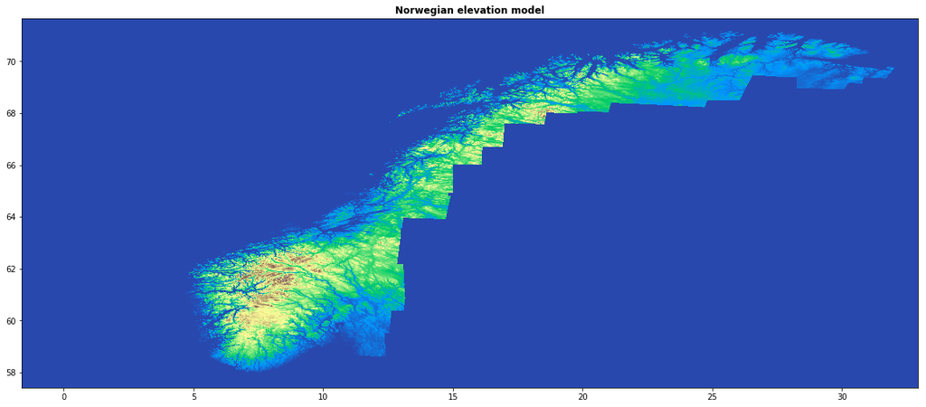

```python
# Initialize subplots
fig, (ax1) = plt.subplots(ncols=1, nrows=1, figsize=(20, 10))

# Plot Red, Green and Blue (rgb)
show((ds), cmap='terrain', title='Norwegian elevation model', ax=ax1)
```

Si dividono le stazioni metereologiche in categorie di altitudine.

```python
infos = [item for item in infos if (item[1][0] > -1.6261) and (item[1][0] < 32.929872)]
infos = [item for item in infos if (item[1][1] > 57.414033) and (item[1][1] < 71.6527914)]
```

```python
elevation=[]
code=[]
for i in range(len(infos)):
    values=[]
    py,px = ds.index(infos[i][1][0], infos[i][1][1])
    c=band[py,px]
    elevation.append(c)
    code.append(infos[i][2])
ds.close()
del band

Elevation=pd.DataFrame(elevation,code)
```

```python
Elevation.reset_index(inplace=True)
Elevation.columns=['code','elevation']
```

```python
airtemp = airtemp.merge(Elevation, on=['code'])
```

```python
airtemp['elevation_category']=['<= 100m' if x <= 100 else ('<= 500m' if x <= 500 else '> 500m') for x in airtemp['elevation']]
```

```python
####### plottare serie temporali divise per categorie
```

```python
mean_error=airtemp.groupby(['elevation_category','week']).mean()
mean_error_ov=airtemp.groupby(['week']).mean()
```

```python
mean_error.reset_index(inplace=True)
mean_error_ov.reset_index(inplace=True)
```

```python
temp=airtemp.copy()
temp['error']=abs(temp['error'])
absolute_error=temp.groupby(['elevation_category','week']).mean()
absolute_error_ov=temp.groupby(['week']).mean()

absolute_error.reset_index(inplace=True)
absolute_error_ov.reset_index(inplace=True)
```

```python
temp=airtemp.copy()
std=temp.groupby(['elevation_category','week']).std()
std_ov=temp.groupby(['week']).std()
std.reset_index(inplace=True)
std_ov.reset_index(inplace=True)
```

```python
temp=airtemp.copy()
rmse_ov=[]
week_ov=[]
for i in np.arange(1,32):
    x=temp[temp['week']==i]['observed_air_temperature']
    y=temp[temp['week']==i]['forecasted_air_temperature']
    try:
        r=np.sqrt(sm.mean_squared_error(x, y))
    except:
        continue
    rmse_ov.append(r)
    week_ov.append(i)
d={'rmse':rmse_ov,'week':week_ov}
squared_error_ov=pd.DataFrame(d)

categories=[]
rmse=[]
week=[]
for j in list(set(temp['elevation_category'])):
    for i in np.arange(1,32):
        x=temp[(temp['week']==i) & (temp['elevation_category']==j)]['observed_air_temperature']
        y=temp[(temp['week']==i) & (temp['elevation_category']==j)]['forecasted_air_temperature']
        try:
            r=np.sqrt(sm.mean_squared_error(x, y))
        except:
            continue
        rmse.append(r)
        week.append(i)
        categories.append(j)
d={'rmse':rmse,'week':week, 'elevation_category':categories}
squared_error=pd.DataFrame(d)
```

Le stazioni metereologiche vengono divise in tre categorie diverse:  
<= 100m di altitudine  
> 100m & <= 500m di altitudine  
> 500m di altitudine.

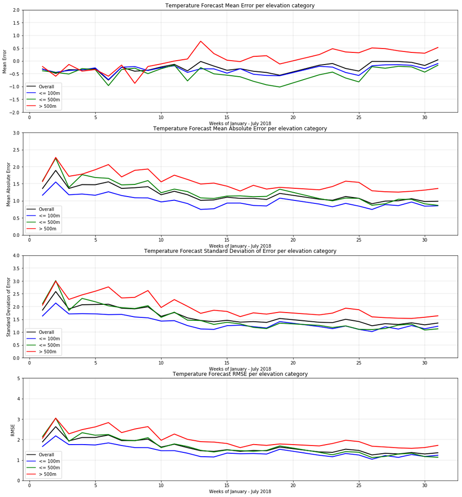

```python
import matplotlib.pyplot as plt
import matplotlib.patches as mpatches
import matplotlib.lines as mlines

plt.figure(figsize=(18,20))

plt.subplot(4, 1, 1)
axes = plt.gca()
axes.set_ylim([-2,2])
plt.grid(color='black', linestyle='-', linewidth=0.1)
plt.title('Temperature Forecast Mean Error per elevation category')
plt.ylabel('Mean Error')
plt.xlabel('Weeks of January - July 2018')
plt.plot( 'week', 'error', data=mean_error_ov, linewidth=2, c='black')
plt.plot( 'week', 'error', data=mean_error[mean_error['elevation_category']=='<= 100m'], linewidth=2, c='blue')
plt.plot( 'week', 'error', data=mean_error[mean_error['elevation_category']=='<= 500m'], linewidth=2, c='green')
plt.plot( 'week', 'error', data=mean_error[mean_error['elevation_category']=='> 500m'], linewidth=2, c='red')
black_line = mlines.Line2D([], [], color='black',markersize=15, label='Overall')
orange_line = mlines.Line2D([], [], color='blue', markersize=15, label='<= 100m')
red_line = mlines.Line2D([], [], color='green', markersize=15, label='<= 500m')
purple_line = mlines.Line2D([], [], color='red', markersize=15, label='> 500m')
handles = [black_line,orange_line,red_line,purple_line]
labels = [h.get_label() for h in handles]
plt.legend(handles=handles, labels=labels,loc='lower left')

plt.subplot(4, 1, 2)
axes = plt.gca()
axes.set_ylim([0,3])
plt.grid(color='black', linestyle='-', linewidth=0.1)
plt.title('Temperature Forecast Mean Absolute Error per elevation category')
plt.ylabel('Mean Absolute Error')
plt.xlabel('Weeks of January - July 2018')
plt.plot( 'week', 'error', data=absolute_error_ov, linewidth=2, c='black')
plt.plot( 'week', 'error', data=absolute_error[absolute_error['elevation_category']=='<= 100m'], linewidth=2, c='blue')
plt.plot( 'week', 'error', data=absolute_error[absolute_error['elevation_category']=='<= 500m'], linewidth=2, c='green')
plt.plot( 'week', 'error', data=absolute_error[absolute_error['elevation_category']=='> 500m'], linewidth=2, c='red')
black_line = mlines.Line2D([], [], color='black',markersize=15, label='Overall')
orange_line = mlines.Line2D([], [], color='blue', markersize=15, label='<= 100m')
red_line = mlines.Line2D([], [], color='green', markersize=15, label='<= 500m')
purple_line = mlines.Line2D([], [], color='red', markersize=15, label='> 500m')
handles = [black_line,orange_line,red_line,purple_line]
labels = [h.get_label() for h in handles]
plt.legend(handles=handles, labels=labels,loc='lower left')

plt.subplot(4, 1, 3)
axes = plt.gca()
axes.set_ylim([0,4])
plt.grid(color='black', linestyle='-', linewidth=0.1)
plt.title('Temperature Forecast Standard Deviation of Error per elevation category')
plt.ylabel('Standard Deviation of Error')
plt.xlabel('Weeks of January - July 2018')
plt.plot( 'week', 'error', data=std_ov, linewidth=2, c='black')
plt.plot( 'week', 'error', data=std[std['elevation_category']=='<= 100m'], linewidth=2, c='blue')
plt.plot( 'week', 'error', data=std[std['elevation_category']=='<= 500m'], linewidth=2, c='green')
plt.plot( 'week', 'error', data=std[std['elevation_category']=='> 500m'], linewidth=2, c='red')
black_line = mlines.Line2D([], [], color='black',markersize=15, label='Overall')
orange_line = mlines.Line2D([], [], color='blue', markersize=15, label='<= 100m')
red_line = mlines.Line2D([], [], color='green', markersize=15, label='<= 500m')
purple_line = mlines.Line2D([], [], color='red', markersize=15, label='> 500m')
handles = [black_line,orange_line,red_line,purple_line]
labels = [h.get_label() for h in handles]
plt.legend(handles=handles, labels=labels,loc='lower left')

plt.subplot(4, 1, 4)
axes = plt.gca()
axes.set_ylim([0,5])
plt.grid(color='black', linestyle='-', linewidth=0.1)
plt.title('Temperature Forecast RMSE per elevation category')
plt.ylabel('RMSE')
plt.xlabel('Weeks of January - July 2018')
plt.plot( 'week', 'rmse', data=squared_error_ov, linewidth=2, c='black')
plt.plot( 'week', 'rmse', data=squared_error[squared_error['elevation_category']=='<= 100m'], linewidth=2, c='blue')
plt.plot( 'week', 'rmse', data=squared_error[squared_error['elevation_category']=='<= 500m'], linewidth=2, c='green')
plt.plot( 'week', 'rmse', data=squared_error[squared_error['elevation_category']=='> 500m'], linewidth=2, c='red')
black_line = mlines.Line2D([], [], color='black',markersize=15, label='Overall')
orange_line = mlines.Line2D([], [], color='blue', markersize=15, label='<= 100m')
red_line = mlines.Line2D([], [], color='green', markersize=15, label='<= 500m')
purple_line = mlines.Line2D([], [], color='red', markersize=15, label='> 500m')
handles = [black_line,orange_line,red_line,purple_line]
labels = [h.get_label() for h in handles]
plt.legend(handles=handles, labels=labels,loc='lower left')

plt.show()
```

Questa suddivisione evidenzia come le categorie proposte abbiano in effetti comportamenti consistentemente diversi in termini di errore registrato dei forecast.  
I forecast attorno alle stazioni con altitudine superiore ai 500m sono, come era possibile anticipare, peggiori.  
Questa può essere una prima indicazione di come forecast prodotti per punti nello spazio che presentano asperità del terreno possano essere sistematicamente peggiori.

Utilizzando i dati sull'elevazione portati in dote dai DEMs è possibile calcolare il TPI, Topographic Position Index.  
source: http://www.jennessent.com/downloads/tpi-poster-tnc_18x22.pdf  
Il TPI compara l'elevazione di ogni cella in un DEM con l'elevazione media di uno specifico range di celle vicine. Il valore calcolato viene poi standardizzato ed è considerabile un indice di asperità del terreno attorno a una data cella.

```python
ds=rio.open('/data/davidg/DEMs/Norway-4326.tif')
band=ds.read(1)

count=0
hm_TPI=[]
code=[]
for i in range(len(infos)):
    values=[]
    py,px = ds.index(infos[i][1][0], infos[i][1][1])
    try:
        c=band[py,px]
    except IndexError:
        hm_TPI.append(None)
        continue
    h=np.concatenate((np.arange(py-1250,py-249,1), np.arange(py+250,py+1251,1)), axis=None)
    w=np.concatenate((np.arange(px-1250,px-249,1), np.arange(px+250,px+1251,1)), axis=None)
    for z in h:
        for j in w:
            try:
                n=band[z,j]
            except IndexError:
                    continue
            values.append(n)
    hm_TPI.append(int((c-np.array(values).mean())+.5))
    code.append(infos[i][2])
    count=count+1
    print(count,'/',len(infos), end='\r', flush=True)

ds.close()
del band
```

```
337 / 337
```

```python
tpi=pd.DataFrame(hm_TPI,code)
tpi.reset_index(inplace=True)
tpi.columns=['code','tpi']
```

```python
airtemp = airtemp.merge(tpi, on=['code'])
```

```python
airtemp['sd_tpi'] = preprocessing.scale(airtemp['tpi'])
```

```python
ds=rio.open('/data/davidg/DEMs/slope.tif')
band=ds.read(1)

slope=[]
code=[]
for i in range(len(infos)):
    values=[]
    py,px = ds.index(infos[i][1][0], infos[i][1][1])
    c=band[py,px]
    slope.append(c)
    code.append(infos[i][2])
ds.close()
del band

Slope=pd.DataFrame(slope,code)
Slope.reset_index(inplace=True)
Slope.columns=['code','slope']
```

```python
airtemp = airtemp.merge(Slope, on=['code'])
```

Tramite le funzioni di utility del pacchetto GDAL è possibile, sempre utilizzando i DEM, produrre un altro descrittore del terreno: la *Slope*, ovvero l'inclinazione del terreno stesso.

Combinando TPI e Slope con appositi threshold è possibile suddividere le stazioni metereologiche non più in categorie basate sull'altitudine ma in categorie determinate appunto dal tipo di slope.

```python
slope_category=[]
for i in range(len(airtemp)):
    if airtemp['sd_tpi'][i] > 1:
        slope_category.append('ridge')
    elif (airtemp['sd_tpi'][i] <= 1) & (airtemp['sd_tpi'][i] > 0.5):
        slope_category.append('upper_slope')
    elif (airtemp['sd_tpi'][i] > -0.5) & (airtemp['sd_tpi'][i] < 0.5) & (airtemp['slope'][i] > 5):
        slope_category.append('middle_slope')
    elif (airtemp['sd_tpi'][i] >= -0.5) & (airtemp['sd_tpi'][i] <= 0.5) & (airtemp['slope'][i] <= 5):
        slope_category.append('flats_slope')
    elif (airtemp['sd_tpi'][i] >= -1) & (airtemp['sd_tpi'][i] < 0.5):
        slope_category.append('lower_slopes')
    elif (airtemp['sd_tpi'][i] < -1):
        slope_category.append('valleys')

airtemp['slope_category']=slope_category
```

```python
airtemp.drop(['sd_TPI'], axis=1, inplace=True)
```

```python
airtemp
```

|  | day | week | month | code | weather_station | observed_air_temperature | forecasted_air_temperature | error | elevation | elevation_category | tpi | slope | sd_tpi | slope_category |
| --- | --- | --- | --- | --- | --- | --- | --- | --- | --- | --- | --- | --- | --- | --- |
| 0 | 1 | 1 | 1 | SN93140 | ALTA LUFTHAVN | 268.112500 | 265.909061 | -2.203439 | 2.502128 | <= 100m | -199 | 0.284791 | -0.273286 | flats_slope |
| 1 | 2 | 1 | 1 | SN93140 | ALTA LUFTHAVN | 265.887500 | 267.146080 | 1.258580 | 2.502128 | <= 100m | -199 | 0.284791 | -0.273286 | flats_slope |
| 2 | 3 | 1 | 1 | SN93140 | ALTA LUFTHAVN | 268.137500 | 266.833674 | -1.303826 | 2.502128 | <= 100m | -199 | 0.284791 | -0.273286 | flats_slope |
| 3 | 4 | 1 | 1 | SN93140 | ALTA LUFTHAVN | 269.429167 | 271.021811 | 1.592644 | 2.502128 | <= 100m | -199 | 0.284791 | -0.273286 | flats_slope |
| 4 | 5 | 1 | 1 | SN93140 | ALTA LUFTHAVN | 261.370833 | 265.052022 | 3.681189 | 2.502128 | <= 100m | -199 | 0.284791 | -0.273286 | flats_slope |
| 5 | 6 | 1 | 1 | SN93140 | ALTA LUFTHAVN | 266.825000 | 267.773238 | 0.948238 | 2.502128 | <= 100m | -199 | 0.284791 | -0.273286 | flats_slope |
| 6 | 7 | 1 | 1 | SN93140 | ALTA LUFTHAVN | 265.795833 | 265.402659 | -0.393175 | 2.502128 | <= 100m | -199 | 0.284791 | -0.273286 | flats_slope |
| 7 | 8 | 2 | 1 | SN93140 | ALTA LUFTHAVN | 271.829167 | 270.361728 | -1.467438 | 2.502128 | <= 100m | -199 | 0.284791 | -0.273286 | flats_slope |
| 8 | 9 | 2 | 1 | SN93140 | ALTA LUFTHAVN | 269.104167 | 268.401317 | -0.702849 | 2.502128 | <= 100m | -199 | 0.284791 | -0.273286 | flats_slope |
| 9 | 10 | 2 | 1 | SN93140 | ALTA LUFTHAVN | 272.662500 | 271.819768 | -0.842732 | 2.502128 | <= 100m | -199 | 0.284791 | -0.273286 | flats_slope |
| 10 | 11 | 2 | 1 | SN93140 | ALTA LUFTHAVN | 268.754167 | 268.068339 | -0.685828 | 2.502128 | <= 100m | -199 | 0.284791 | -0.273286 | flats_slope |
| 11 | 12 | 2 | 1 | SN93140 | ALTA LUFTHAVN | 270.200000 | 271.847076 | 1.647076 | 2.502128 | <= 100m | -199 | 0.284791 | -0.273286 | flats_slope |
| 12 | 13 | 2 | 1 | SN93140 | ALTA LUFTHAVN | 271.741667 | 268.804839 | -2.936828 | 2.502128 | <= 100m | -199 | 0.284791 | -0.273286 | flats_slope |
| 13 | 14 | 2 | 1 | SN93140 | ALTA LUFTHAVN | 264.983333 | 265.400277 | 0.416944 | 2.502128 | <= 100m | -199 | 0.284791 | -0.273286 | flats_slope |
| 14 | 15 | 3 | 1 | SN93140 | ALTA LUFTHAVN | 269.762500 | 267.486047 | -2.276453 | 2.502128 | <= 100m | -199 | 0.284791 | -0.273286 | flats_slope |
| 15 | 16 | 3 | 1 | SN93140 | ALTA LUFTHAVN | 267.754167 | 267.727471 | -0.026695 | 2.502128 | <= 100m | -199 | 0.284791 | -0.273286 | flats_slope |
| 16 | 17 | 3 | 1 | SN93140 | ALTA LUFTHAVN | 263.483333 | 263.674778 | 0.191444 | 2.502128 | <= 100m | -199 | 0.284791 | -0.273286 | flats_slope |
| 17 | 18 | 3 | 1 | SN93140 | ALTA LUFTHAVN | 259.587500 | 257.816639 | -1.770861 | 2.502128 | <= 100m | -199 | 0.284791 | -0.273286 | flats_slope |
| 18 | 19 | 3 | 1 | SN93140 | ALTA LUFTHAVN | 261.795833 | 260.863647 | -0.932186 | 2.502128 | <= 100m | -199 | 0.284791 | -0.273286 | flats_slope |
| 19 | 20 | 3 | 1 | SN93140 | ALTA LUFTHAVN | 260.516667 | 259.191954 | -1.324713 | 2.502128 | <= 100m | -199 | 0.284791 | -0.273286 | flats_slope |
| 20 | 21 | 3 | 1 | SN93140 | ALTA LUFTHAVN | 260.229167 | 259.700987 | -0.528179 | 2.502128 | <= 100m | -199 | 0.284791 | -0.273286 | flats_slope |
| 21 | 22 | 4 | 1 | SN93140 | ALTA LUFTHAVN | 258.591667 | 258.391542 | -0.200125 | 2.502128 | <= 100m | -199 | 0.284791 | -0.273286 | flats_slope |
| 22 | 23 | 4 | 1 | SN93140 | ALTA LUFTHAVN | 257.862500 | 257.835971 | -0.026529 | 2.502128 | <= 100m | -199 | 0.284791 | -0.273286 | flats_slope |
| 23 | 24 | 4 | 1 | SN93140 | ALTA LUFTHAVN | 255.412500 | 253.486594 | -1.925906 | 2.502128 | <= 100m | -199 | 0.284791 | -0.273286 | flats_slope |
| 24 | 25 | 4 | 1 | SN93140 | ALTA LUFTHAVN | 260.858333 | 261.987433 | 1.129100 | 2.502128 | <= 100m | -199 | 0.284791 | -0.273286 | flats_slope |
| 25 | 26 | 4 | 1 | SN93140 | ALTA LUFTHAVN | 269.812500 | 270.643453 | 0.830953 | 2.502128 | <= 100m | -199 | 0.284791 | -0.273286 | flats_slope |
| 26 | 27 | 4 | 1 | SN93140 | ALTA LUFTHAVN | 263.729167 | 264.032632 | 0.303465 | 2.502128 | <= 100m | -199 | 0.284791 | -0.273286 | flats_slope |
| 27 | 28 | 4 | 1 | SN93140 | ALTA LUFTHAVN | 258.987500 | 257.981851 | -1.005649 | 2.502128 | <= 100m | -199 | 0.284791 | -0.273286 | flats_slope |
| 28 | 29 | 5 | 1 | SN93140 | ALTA LUFTHAVN | 263.120833 | 259.610331 | -3.510502 | 2.502128 | <= 100m | -199 | 0.284791 | -0.273286 | flats_slope |
| 29 | 30 | 5 | 1 | SN93140 | ALTA LUFTHAVN | 263.545833 | 262.062469 | -1.483364 | 2.502128 | <= 100m | -199 | 0.284791 | -0.273286 | flats_slope |
| ... | ... | ... | ... | ... | ... | ... | ... | ... | ... | ... | ... | ... | ... | ... |
| 65154 | 2 | 27 | 7 | SN13750 | ØVRE HEIMDALSVATN | 289.308333 | 287.139038 | -2.169295 | 1096.722290 | > 500m | -107 | 0.644449 | 0.021494 | flats_slope |
| 65155 | 3 | 27 | 7 | SN13750 | ØVRE HEIMDALSVATN | 288.404167 | 287.187938 | -1.216228 | 1096.722290 | > 500m | -107 | 0.644449 | 0.021494 | flats_slope |
| 65156 | 4 | 27 | 7 | SN13750 | ØVRE HEIMDALSVATN | 290.862500 | 289.056270 | -1.806230 | 1096.722290 | > 500m | -107 | 0.644449 | 0.021494 | flats_slope |
| 65157 | 5 | 27 | 7 | SN13750 | ØVRE HEIMDALSVATN | 290.504167 | 289.026430 | -1.477736 | 1096.722290 | > 500m | -107 | 0.644449 | 0.021494 | flats_slope |
| 65158 | 6 | 27 | 7 | SN13750 | ØVRE HEIMDALSVATN | 286.070833 | 285.383243 | -0.687590 | 1096.722290 | > 500m | -107 | 0.644449 | 0.021494 | flats_slope |
| 65159 | 7 | 27 | 7 | SN13750 | ØVRE HEIMDALSVATN | 285.554167 | 284.261268 | -1.292898 | 1096.722290 | > 500m | -107 | 0.644449 | 0.021494 | flats_slope |
| 65160 | 8 | 27 | 7 | SN13750 | ØVRE HEIMDALSVATN | 287.462500 | 285.401583 | -2.060917 | 1096.722290 | > 500m | -107 | 0.644449 | 0.021494 | flats_slope |
| 65161 | 9 | 28 | 7 | SN13750 | ØVRE HEIMDALSVATN | 281.908333 | 280.396555 | -1.511778 | 1096.722290 | > 500m | -107 | 0.644449 | 0.021494 | flats_slope |
| 65162 | 10 | 28 | 7 | SN13750 | ØVRE HEIMDALSVATN | 287.350000 | 285.833027 | -1.516973 | 1096.722290 | > 500m | -107 | 0.644449 | 0.021494 | flats_slope |
| 65163 | 11 | 28 | 7 | SN13750 | ØVRE HEIMDALSVATN | 288.608333 | 286.800639 | -1.807695 | 1096.722290 | > 500m | -107 | 0.644449 | 0.021494 | flats_slope |
| 65164 | 12 | 28 | 7 | SN13750 | ØVRE HEIMDALSVATN | 287.195833 | 286.252692 | -0.943142 | 1096.722290 | > 500m | -107 | 0.644449 | 0.021494 | flats_slope |
| 65165 | 13 | 28 | 7 | SN13750 | ØVRE HEIMDALSVATN | 287.145833 | 285.307225 | -1.838608 | 1096.722290 | > 500m | -107 | 0.644449 | 0.021494 | flats_slope |
| 65166 | 14 | 28 | 7 | SN13750 | ØVRE HEIMDALSVATN | 288.470833 | 287.743863 | -0.726970 | 1096.722290 | > 500m | -107 | 0.644449 | 0.021494 | flats_slope |
| 65167 | 15 | 28 | 7 | SN13750 | ØVRE HEIMDALSVATN | 289.720833 | 289.339924 | -0.380910 | 1096.722290 | > 500m | -107 | 0.644449 | 0.021494 | flats_slope |
| 65168 | 16 | 29 | 7 | SN13750 | ØVRE HEIMDALSVATN | 291.312500 | 289.847717 | -1.464783 | 1096.722290 | > 500m | -107 | 0.644449 | 0.021494 | flats_slope |
| 65169 | 17 | 29 | 7 | SN13750 | ØVRE HEIMDALSVATN | 288.708333 | 288.181736 | -0.526598 | 1096.722290 | > 500m | -107 | 0.644449 | 0.021494 | flats_slope |
| 65170 | 18 | 29 | 7 | SN13750 | ØVRE HEIMDALSVATN | 286.404167 | 284.802622 | -1.601544 | 1096.722290 | > 500m | -107 | 0.644449 | 0.021494 | flats_slope |
| 65171 | 19 | 29 | 7 | SN13750 | ØVRE HEIMDALSVATN | 288.045833 | 286.039090 | -2.006743 | 1096.722290 | > 500m | -107 | 0.644449 | 0.021494 | flats_slope |
| 65172 | 20 | 29 | 7 | SN13750 | ØVRE HEIMDALSVATN | 288.925000 | 288.474435 | -0.450565 | 1096.722290 | > 500m | -107 | 0.644449 | 0.021494 | flats_slope |
| 65173 | 21 | 29 | 7 | SN13750 | ØVRE HEIMDALSVATN | 288.895833 | 287.948404 | -0.947430 | 1096.722290 | > 500m | -107 | 0.644449 | 0.021494 | flats_slope |
| 65174 | 22 | 29 | 7 | SN13750 | ØVRE HEIMDALSVATN | 288.900000 | 287.386464 | -1.513536 | 1096.722290 | > 500m | -107 | 0.644449 | 0.021494 | flats_slope |
| 65175 | 23 | 30 | 7 | SN13750 | ØVRE HEIMDALSVATN | 288.275000 | 287.352021 | -0.922979 | 1096.722290 | > 500m | -107 | 0.644449 | 0.021494 | flats_slope |
| 65176 | 24 | 30 | 7 | SN13750 | ØVRE HEIMDALSVATN | 289.983333 | 287.570461 | -2.412872 | 1096.722290 | > 500m | -107 | 0.644449 | 0.021494 | flats_slope |
| 65177 | 25 | 30 | 7 | SN13750 | ØVRE HEIMDALSVATN | 288.795833 | 286.944130 | -1.851704 | 1096.722290 | > 500m | -107 | 0.644449 | 0.021494 | flats_slope |
| 65178 | 26 | 30 | 7 | SN13750 | ØVRE HEIMDALSVATN | 288.579167 | 287.584526 | -0.994641 | 1096.722290 | > 500m | -107 | 0.644449 | 0.021494 | flats_slope |
| 65179 | 27 | 30 | 7 | SN13750 | ØVRE HEIMDALSVATN | 291.875000 | 291.417420 | -0.457580 | 1096.722290 | > 500m | -107 | 0.644449 | 0.021494 | flats_slope |
| 65180 | 28 | 30 | 7 | SN13750 | ØVRE HEIMDALSVATN | 289.879167 | 288.706351 | -1.172816 | 1096.722290 | > 500m | -107 | 0.644449 | 0.021494 | flats_slope |
| 65181 | 29 | 30 | 7 | SN13750 | ØVRE HEIMDALSVATN | 289.304167 | 286.493015 | -2.811152 | 1096.722290 | > 500m | -107 | 0.644449 | 0.021494 | flats_slope |
| 65182 | 30 | 31 | 7 | SN13750 | ØVRE HEIMDALSVATN | 285.529167 | 284.863472 | -0.665695 | 1096.722290 | > 500m | -107 | 0.644449 | 0.021494 | flats_slope |
| 65183 | 31 | 31 | 7 | SN13750 | ØVRE HEIMDALSVATN | 288.466667 | 285.795171 | -2.671496 | 1096.722290 | > 500m | -107 | 0.644449 | 0.021494 | flats_slope |

65184 rows × 14 columns

```python
###### plottare serie temporali divise per categorie tpi
```

```python
mean_error=airtemp.groupby(['slope_category','week']).mean()
mean_error_ov=airtemp.groupby(['week']).mean()
mean_error.reset_index(inplace=True)
mean_error_ov.reset_index(inplace=True)
```

```python
temp=airtemp.copy()
temp['error']=abs(temp['error'])
absolute_error=temp.groupby(['slope_category','week']).mean()
absolute_error_ov=temp.groupby(['week']).mean()

absolute_error.reset_index(inplace=True)
absolute_error_ov.reset_index(inplace=True)
```

```python
temp=airtemp.copy()
std=temp.groupby(['slope_category','week']).std()
std_ov=temp.groupby(['week']).std()
std.reset_index(inplace=True)
std_ov.reset_index(inplace=True)
```

```python
temp=airtemp.copy()
rmse_ov=[]
week_ov=[]
for i in np.arange(1,32):
    x=temp[temp['week']==i]['observed_air_temperature']
    y=temp[temp['week']==i]['forecasted_air_temperature']
    try:
        r=np.sqrt(sm.mean_squared_error(x, y))
    except:
        continue
    rmse_ov.append(r)
    week_ov.append(i)
d={'rmse':rmse_ov,'week':week_ov}
squared_error_ov=pd.DataFrame(d)

categories=[]
rmse=[]
week=[]
for j in list(set(temp['slope_category'])):
    for i in np.arange(1,32):
        x=temp[(temp['week']==i) & (temp['slope_category']==j)]['observed_air_temperature']
        y=temp[(temp['week']==i) & (temp['slope_category']==j)]['forecasted_air_temperature']
        try:
            r=np.sqrt(sm.mean_squared_error(x, y))
        except:
            continue
        rmse.append(r)
        week.append(i)
        categories.append(j)
d={'rmse':rmse,'week':week, 'slope_category':categories}
squared_error=pd.DataFrame(d)
```

Si plottano dunque le serie temporali dell'errore dei forecast per le varie categorie di slope.

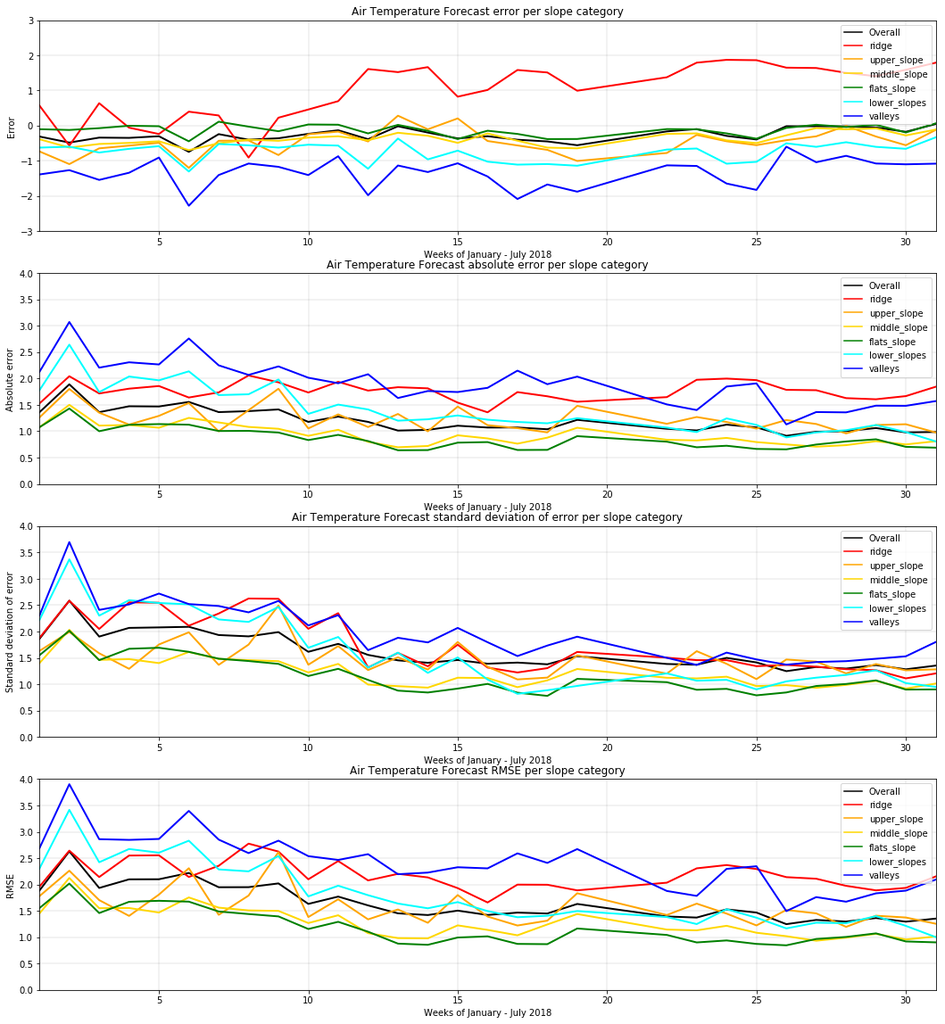

```python
import matplotlib.pyplot as plt
import matplotlib.patches as mpatches
import matplotlib.lines as mlines

plt.figure(figsize=(18,20))

plt.subplot(4, 1, 1)
axes = plt.gca()
axes.set_ylim([-3,3])
axes.set_xlim([1,31])
plt.grid(color='black', linestyle='-', linewidth=0.1)
plt.title('Air Temperature Forecast error per slope category')
plt.ylabel('Error')
plt.xlabel('Weeks of January - July 2018')
plt.plot( 'week', 'error', data=mean_error_ov, linewidth=2, c='black')
black_line = mlines.Line2D([], [], color='black',markersize=15, label='Overall')
handles = [black_line]
slopes=['ridge','upper_slope','middle_slope','flats_slope','lower_slopes','valleys']
colors=['red','orange','gold','green','cyan','blue']
for i,j in zip(slopes,colors):
    plt.plot( 'week', 'error', data=mean_error[mean_error['slope_category']==i], linewidth=2, c=j)
    new_line = mlines.Line2D([], [], color=j, markersize=15, label=i)
    handles.append(new_line)
labels = [h.get_label() for h in handles]
plt.legend(handles=handles, labels=labels,loc='upper right')

plt.subplot(4, 1, 2)
axes = plt.gca()
axes.set_ylim([0,4])
axes.set_xlim([1,31])
plt.grid(color='black', linestyle='-', linewidth=0.1)
plt.title('Air Temperature Forecast absolute error per slope category')
plt.ylabel('Absolute error')
plt.xlabel('Weeks of January - July 2018')
plt.plot( 'week', 'error', data=absolute_error_ov, linewidth=2, c='black')
black_line = mlines.Line2D([], [], color='black',markersize=15, label='Overall')
handles = [black_line]
slopes=['ridge','upper_slope','middle_slope','flats_slope','lower_slopes','valleys']
colors=['red','orange','gold','green','cyan','blue']
for i,j in zip(slopes,colors):
    plt.plot( 'week', 'error', data=absolute_error[absolute_error['slope_category']==i], linewidth=2, c=j)
    new_line = mlines.Line2D([], [], color=j, markersize=15, label=i)
    handles.append(new_line)
labels = [h.get_label() for h in handles]
plt.legend(handles=handles, labels=labels,loc='upper right')

plt.subplot(4, 1, 3)
axes = plt.gca()
axes.set_ylim([0,4])
axes.set_xlim([1,31])
plt.grid(color='black', linestyle='-', linewidth=0.1)
plt.title('Air Temperature Forecast standard deviation of error per slope category')
plt.ylabel('Standard deviation of error')
plt.xlabel('Weeks of January - July 2018')
plt.plot( 'week', 'error', data=std_ov, linewidth=2, c='black')
black_line = mlines.Line2D([], [], color='black',markersize=15, label='Overall')
handles = [black_line]
slopes=['ridge','upper_slope','middle_slope','flats_slope','lower_slopes','valleys']
colors=['red','orange','gold','green','cyan','blue']
for i,j in zip(slopes,colors):
    plt.plot( 'week', 'error', data=std[std['slope_category']==i], linewidth=2, c=j)
    new_line = mlines.Line2D([], [], color=j, markersize=15, label=i)
    handles.append(new_line)
labels = [h.get_label() for h in handles]
plt.legend(handles=handles, labels=labels,loc='upper right')

plt.subplot(4, 1, 4)
axes = plt.gca()
axes.set_ylim([0,4])
axes.set_xlim([1,31])
plt.grid(color='black', linestyle='-', linewidth=0.1)
plt.title('Air Temperature Forecast RMSE per slope category')
plt.ylabel('RMSE')
plt.xlabel('Weeks of January - July 2018')
plt.plot( 'week', 'rmse', data=squared_error_ov, linewidth=2, c='black')
black_line = mlines.Line2D([], [], color='black',markersize=15, label='Overall')
handles = [black_line]
slopes=['ridge','upper_slope','middle_slope','flats_slope','lower_slopes','valleys']
colors=['red','orange','gold','green','cyan','blue']
for i,j in zip(slopes,colors):
    plt.plot( 'week', 'rmse', data=squared_error[squared_error['slope_category']==i], linewidth=2, c=j)
    new_line = mlines.Line2D([], [], color=j, markersize=15, label=i)
    handles.append(new_line)
labels = [h.get_label() for h in handles]
plt.legend(handles=handles, labels=labels,loc='upper right')

plt.show()
```

Si nota come ci siano categorie che si assestano consistentemente sopra o sotto la media.  
Se era più prevedibile trovare *ridge* sopra la media, è interessante invece la presenza di *valley* come categoria di terreno sulla quale gli errori dei forecast sono più alti.

## Conclusioni

Dopo aver determinato come la qualità dei forecast non sia uniformemente distribuita nello spazio è stato possibile investigare a che cosa fosse attribuibile tale difformità.  
È stato possibile concludere come il forecasting di eventi metereologici estremi renda più difficile il forecasting stesso, e come sia possibile associare la conformazione del terreno alla qualità del forecast prodotto per un dato punto dello spazio.